# Homework 4

Tim Potter

March 3, 2019

# Questions

```r
weight0 <- chick %>%
  group_by(Diet) %>%
  summarize(n=n(), avgWeight = mean(weight), sdWeight = sd(weight))
weight0
```

```
## # A tibble: 4 x 4
##   Diet      n avgWeight sdWeight
##   <fct> <int>     <dbl>    <dbl>
## 1 1       220      103.     56.7
## 2 2       120      123.     71.6
## 3 3       120      143.     86.5
## 4 4       118      135.     68.8
```

```r
count <- chick %>%
  group_by(Chick) %>%
  mutate(Count = n()) %>%
  ungroup()
complete <- count %>%
  filter(Count==12)
head(complete, 3)
```

```
## # A tibble: 3 x 5
##   weight  Time Chick Diet  Count
##    <dbl> <dbl> <ord> <fct> <int>
## 1     42     0 1     1        12
## 2     51     2 1     1        12
## 3     59     4 1     1        12
```

```r
complete <- complete %>%
  group_by(Chick) %>%
  mutate(weightgain = weight - weight[Time == 0]) %>%
  ungroup()
head(complete, 3)
```

```
## # A tibble: 3 x 6
##   weight  Time Chick Diet  Count weightgain
##    <dbl> <dbl> <ord> <fct> <int>      <dbl>
## 1     42     0 1     1        12          0
## 2     51     2 1     1        12          9
## 3     59     4 1     1        12         17
```

4. Going by the graph, the chicks on diet 3 gained the most weight by day 21, while the chicks on diet 1 gained the least. The chicks on diet 2 had the largest spread of weights, and the chicks on diet 4 had the tightest spread.

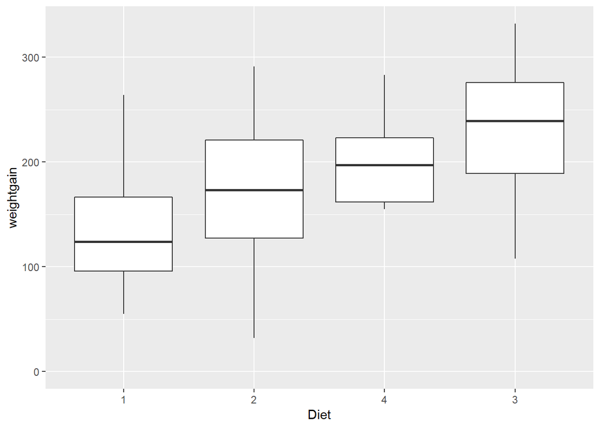

```r
complete$Diet <- factor(complete$Diet, c(1, 2, 4, 3))

complete %>%
  filter(Time == 21) %>%
  ggplot(aes(x = Diet, y = weightgain)) + geom_boxplot() + ylim(0, NA)
```

5. Chick 35 gained the most weight. It was on diet 3. Chick 24 gained the least weight. It was on diet 2.

```r
fin <- complete %>%
  filter(Time == 21) %>%
  arrange(desc(weightgain))
fin
```

```
## # A tibble: 45 x 6
##    weight  Time Chick Diet  Count weightgain
##     <dbl> <dbl> <ord> <fct> <int>      <dbl>
##  1    373    21 35    3        12        332
##  2    341    21 34    3        12        300
##  3    331    21 21    2        12        291
##  4    322    21 48    4        12        283
##  5    321    21 40    3        12        280
##  6    309    21 29    2        12        270
##  7    305    21 7     1        12        264
##  8    305    21 32    3        12        264
##  9    290    21 38    3        12        249
## 10    281    21 42    4        12        239
## # ... with 35 more rows
```

```r
complete %>%
  filter(Time == 21) %>%
  arrange(weightgain)
```

```
## # A tibble: 45 x 6
##    weight  Time Chick Diet  Count weightgain
##     <dbl> <dbl> <ord> <fct> <int>      <dbl>
##  1     74    21 24    2        12         32
##  2     96    21 13    1        12         55
##  3     98    21 9     1        12         56
##  4    117    21 20    1        12         76
##  5    124    21 10    1        12         83
##  6    142    21 17    1        12        100
##  7    150    21 30    2        12        108
##  8    147    21 33    3        12        108
##  9    157    21 19    1        12        114
## 10    157    21 4     1        12        115
## # ... with 35 more rows
```

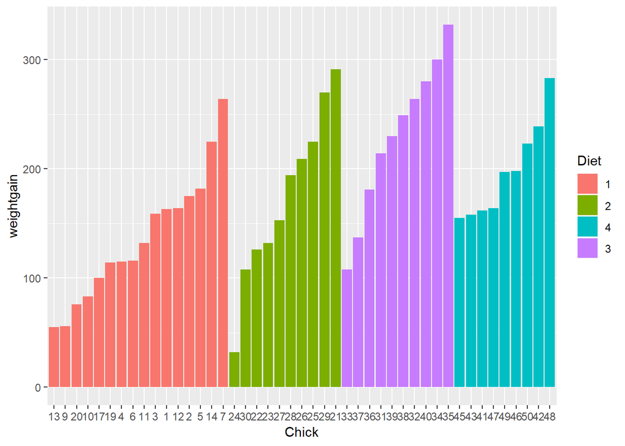

```r
fin %>%
  ggplot(aes(x = Chick, y = weightgain, fill = Diet)) + geom_col()
```

```r
complete %>%
  filter(Time == 0) %>%
  arrange(weight)
```

```
## # A tibble: 45 x 6
##    weight  Time Chick Diet  Count weightgain
##     <dbl> <dbl> <ord> <fct> <int>      <dbl>
##  1     39     0 27    2        12          0
##  2     39     0 28    2        12          0
##  3     39     0 29    2        12          0
##  4     39     0 33    3        12          0
##  5     39     0 36    3        12          0
##  6     39     0 48    4        12          0
##  7     40     0 2     1        12          0
##  8     40     0 21    2        12          0
##  9     40     0 25    2        12          0
## 10     40     0 46    4        12          0
## # ... with 35 more rows
```

```r
complete %>%
  filter(Time == 0) %>%
  arrange(desc(weight))
```

```
## # A tibble: 45 x 6
##    weight  Time Chick Diet  Count weightgain
##     <dbl> <dbl> <ord> <fct> <int>      <dbl>
##  1     43     0 3     1        12          0
##  2     43     0 11    1        12          0
##  3     43     0 19    1        12          0
##  4     43     0 23    2        12          0
##  5     42     0 1     1        12          0
##  6     42     0 4     1        12          0
##  7     42     0 9     1        12          0
##  8     42     0 17    1        12          0
##  9     42     0 24    2        12          0
## 10     42     0 26    2        12          0
## # ... with 35 more rows
```

Chicks 27, 28, 29, 33, 36, and 48 had the lowest starting weight. Chicks 3, 11, 19, and 23 had the heighest starting weight.

```r
complete <- complete %>%
  group_by(Time) %>%
  mutate(avgWeight = sum(weight) / n()) %>%
  ungroup()
complete
```

```
## # A tibble: 540 x 7
##    weight  Time Chick Diet  Count weightgain avgWeight
##     <dbl> <dbl> <ord> <fct> <int>      <dbl>     <dbl>
##  1     42     0 1     1        12          0      41.1
##  2     51     2 1     1        12          9      49.6
##  3     59     4 1     1        12         17      60.2
##  4     64     6 1     1        12         22      74.9
##  5     76     8 1     1        12         34      92.4
##  6     93    10 1     1        12         51     110.
##  7    106    12 1     1        12         64     133.
##  8    125    14 1     1        12         83     146.
##  9    149    16 1     1        12        107     170.
## 10    171    18 1     1        12        129     192.
## # ... with 530 more rows
```

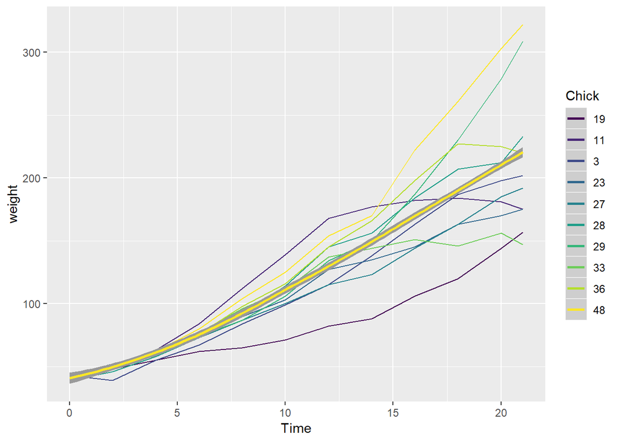

```r
complete %>%
  filter(Chick %in% c(27,28,29,33,36,48,3,11,19,23)) %>%
  ggplot(aes(x = Time, y = weight, color = Chick)) + geom_line() + geom_smooth(aes(x = Time, y = avgWeight), show.legend = TRUE)
```

Chicks with the lowest starting weight

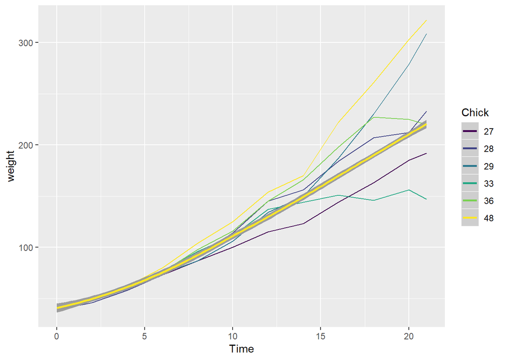

```r
complete %>%
  filter(Chick %in% c(27,28,29,33,36,48)) %>%
  ggplot(aes(x = Time, y = weight, color = Chick)) + geom_line() + geom_smooth(aes(x = Time, y = avgWeight), show.legend = TRUE)
```

Chicks with the heighest starting weight

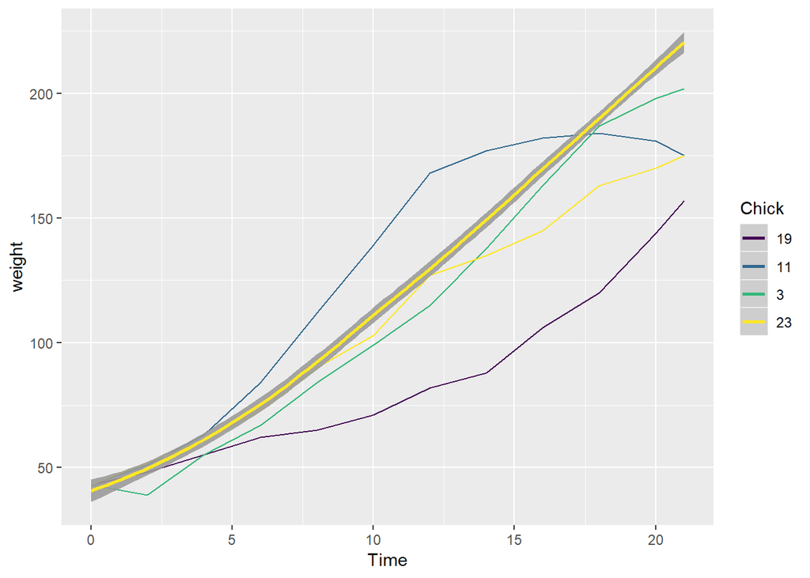

```r
complete %>%
  filter(Chick %in% c(3,11,19,23)) %>%
  ggplot(aes(x = Time, y = weight, color = Chick)) + geom_line() + geom_smooth(aes(x = Time, y = avgWeight), show.legend = TRUE)
```

Note how all the chicks with the heighest starting weight finished below the average weightgain of all the chicks, while several of the lightest chicks ended with a weight greater than the average.

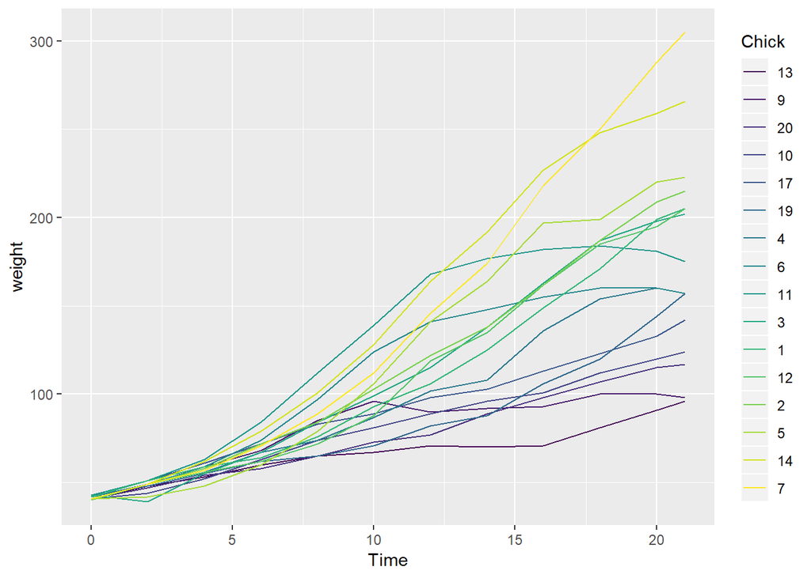

```r
complete %>%
  filter(Diet == 1) %>%
  ggplot(aes(x = Time, y = weight, color = Chick)) + geom_line()
```

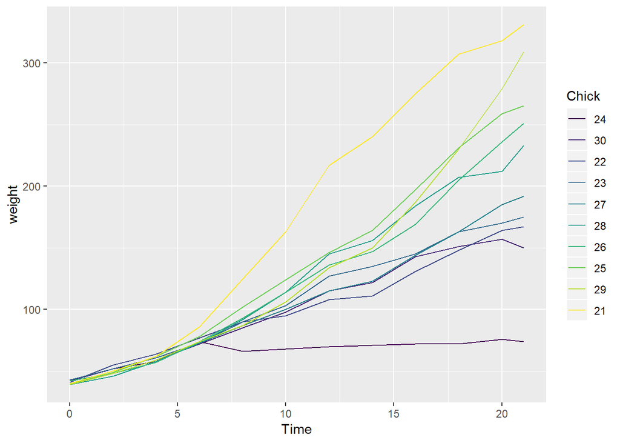

```r
complete %>%
  filter(Diet == 2) %>%
  ggplot(aes(x = Time, y = weight, color = Chick)) + geom_line()
```

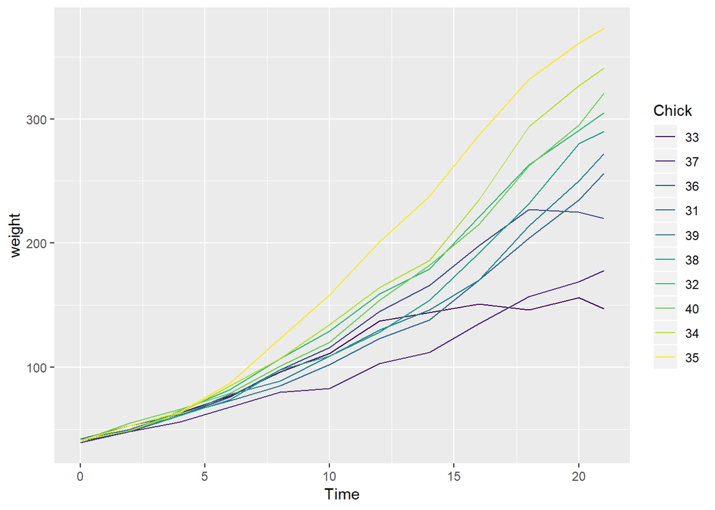

```r
complete %>%
  filter(Diet == 3) %>%
  ggplot(aes(x = Time, y = weight, color = Chick)) + geom_line()
```

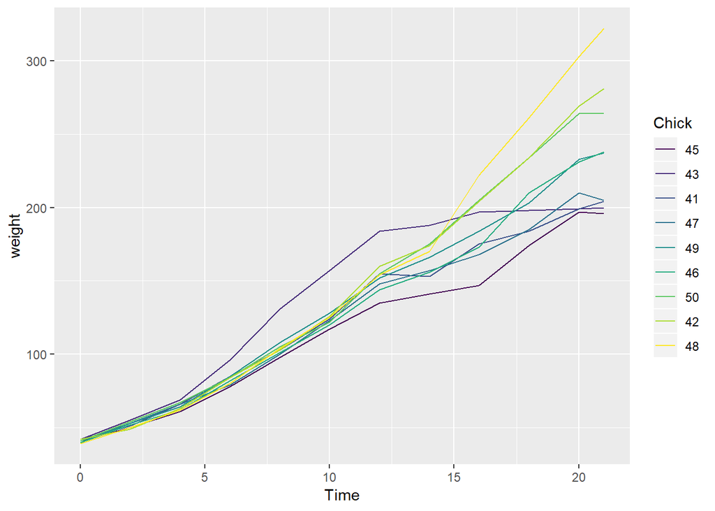

```r
complete %>%
  filter(Diet == 4) %>%
  ggplot(aes(x = Time, y = weight, color = Chick)) + geom_line()
```

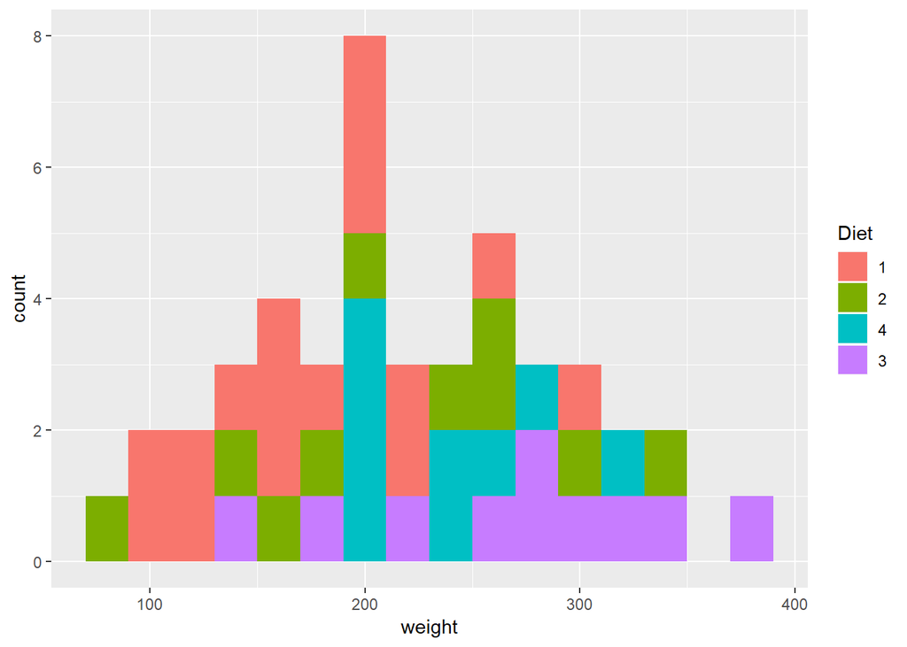

```r
complete %>%
  filter(Time == 21) %>%
  ggplot(aes(x = weight, fill = Diet)) + geom_histogram(binwidth = 20)
```

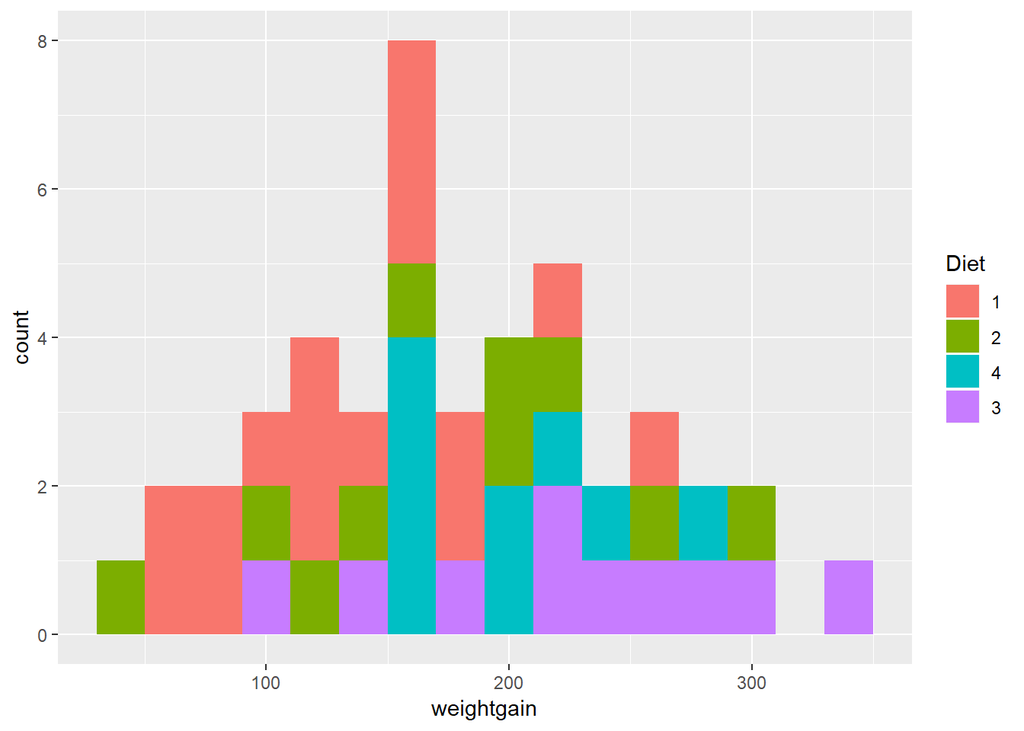

```r
complete %>%
  filter(Time == 21) %>%
  ggplot(aes(x = weightgain, fill = Diet)) + geom_histogram(binwidth = 20)
```

These plots don’t really give us any more information than what we already had.

```r
complete <- complete %>%
  mutate(percentOffAverage = ((weight - avgWeight) / avgWeight) * 100)
complete
```

```
## # A tibble: 540 x 8
##    weight  Time Chick Diet  Count weightgain avgWeight percentOffAverage
##     <dbl> <dbl> <ord> <fct> <int>      <dbl>     <dbl>             <dbl>
##  1     42     0 1     1        12          0      41.1              2.27
##  2     51     2 1     1        12          9      49.6              2.87
##  3     59     4 1     1        12         17      60.2             -1.92
##  4     64     6 1     1        12         22      74.9            -14.5
##  5     76     8 1     1        12         34      92.4            -17.8
##  6     93    10 1     1        12         51     110.             -15.5
##  7    106    12 1     1        12         64     133.             -20.2
##  8    125    14 1     1        12         83     146.             -14.5
##  9    149    16 1     1        12        107     170.             -12.1
## 10    171    18 1     1        12        129     192.             -11.1
## # ... with 530 more rows
```

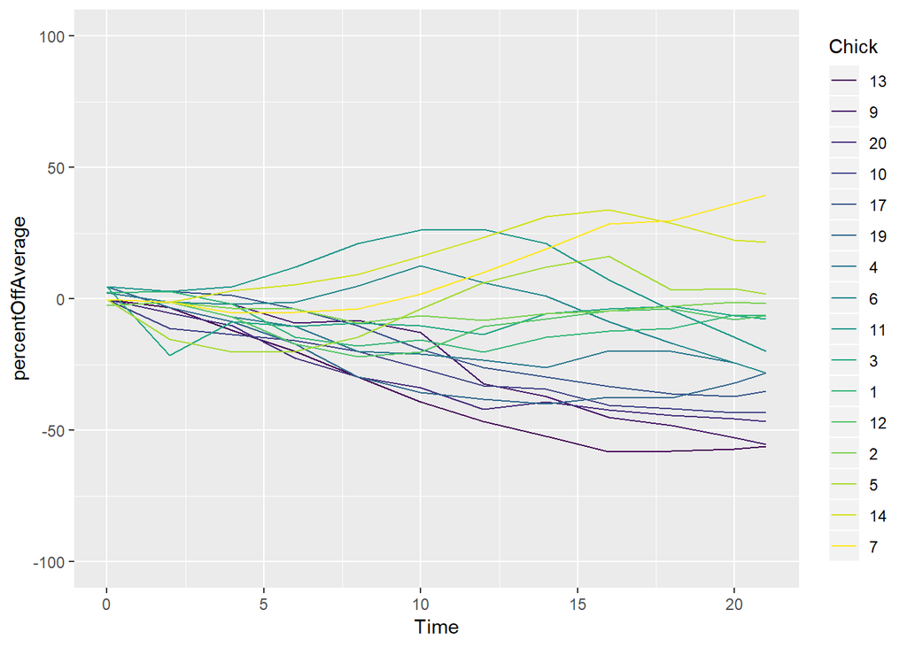

```r
complete %>%
  filter(Diet == 1) %>%
  ggplot(aes(x = Time, y = percentOffAverage, color = Chick)) + geom_line() + ylim(-100,100)
```

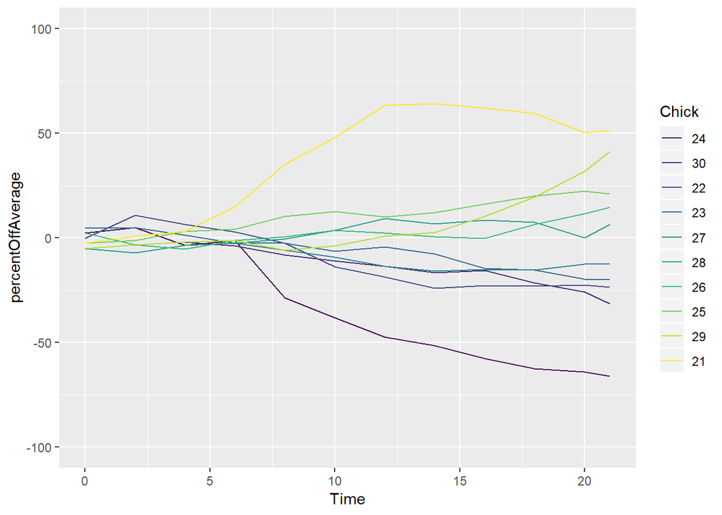

```r
complete %>%
  filter(Diet == 2) %>%
  ggplot(aes(x = Time, y = percentOffAverage, color = Chick)) + geom_line() + ylim(-100,100)
```

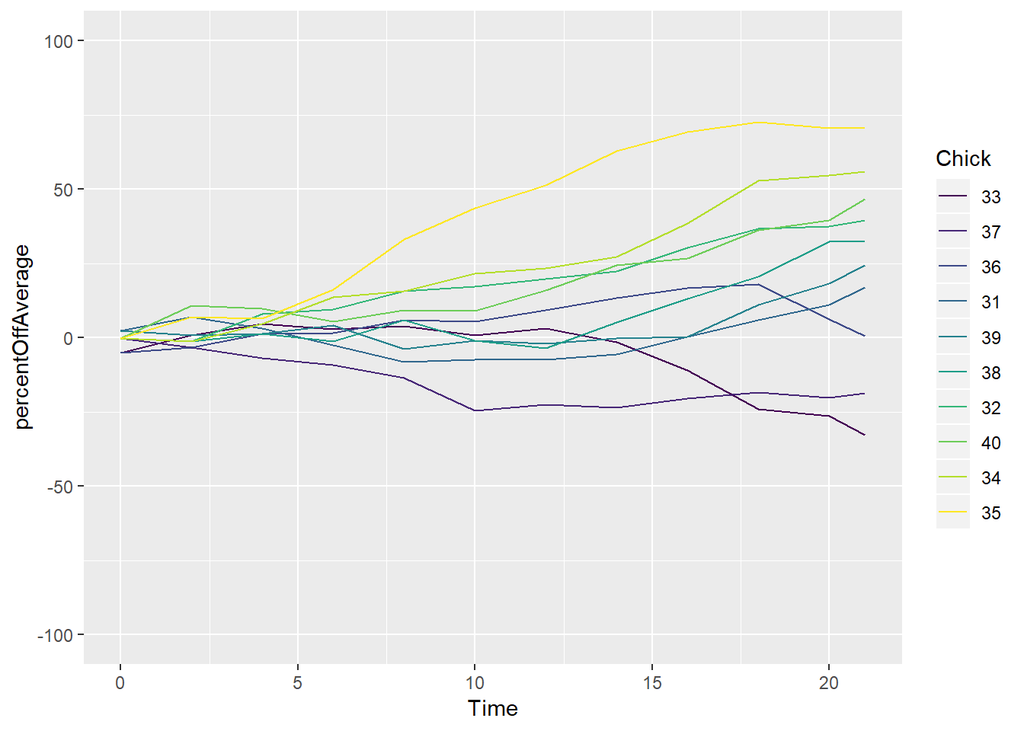

```r
complete %>%
  filter(Diet == 3) %>%
  ggplot(aes(x = Time, y = percentOffAverage, color = Chick)) + geom_line() + ylim(-100,100)
```

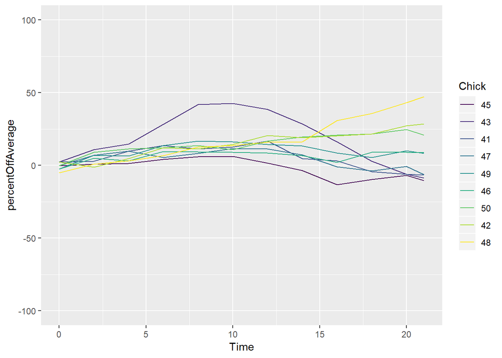

```r
complete %>%
  filter(Diet == 4) %>%
  ggplot(aes(x = Time, y = percentOffAverage, color = Chick)) + geom_line() + ylim(-100,100)
```

These plots show the percentage a chick differed from the average weight on a given day, grouped by the diet of the chick. From these we can see that the chicks on diet 1 were pretty consistently below the average, 3 and 4 were consistently above the average, and diet 2 was pretty much even across the board. Of course there could be several other variables that we’re not taking into account here, *but*, from the data we have examined, it would be safe to say that diets 3 and 4 are the best for gaining weight.